# Simple Linear Regression & Diagnostics

Mariam Walaa

```r
library(car)
library(tidyverse)
```

### Data

This data set comes from the UCI Machine Learning Repository and can be found [here](https://archive.ics.uci.edu/ml/datasets/Facebook+metrics). According to the data abstract, this data set consists of posts published during the year of 2014 on the Facebook pages of a renowned cosmetics brand. The data set contains 500 rows and 19 variables about each post.

```r
facebook <- read.csv(file = '../data/Facebook_metrics/dataset_Facebook.csv', sep = ';')
```

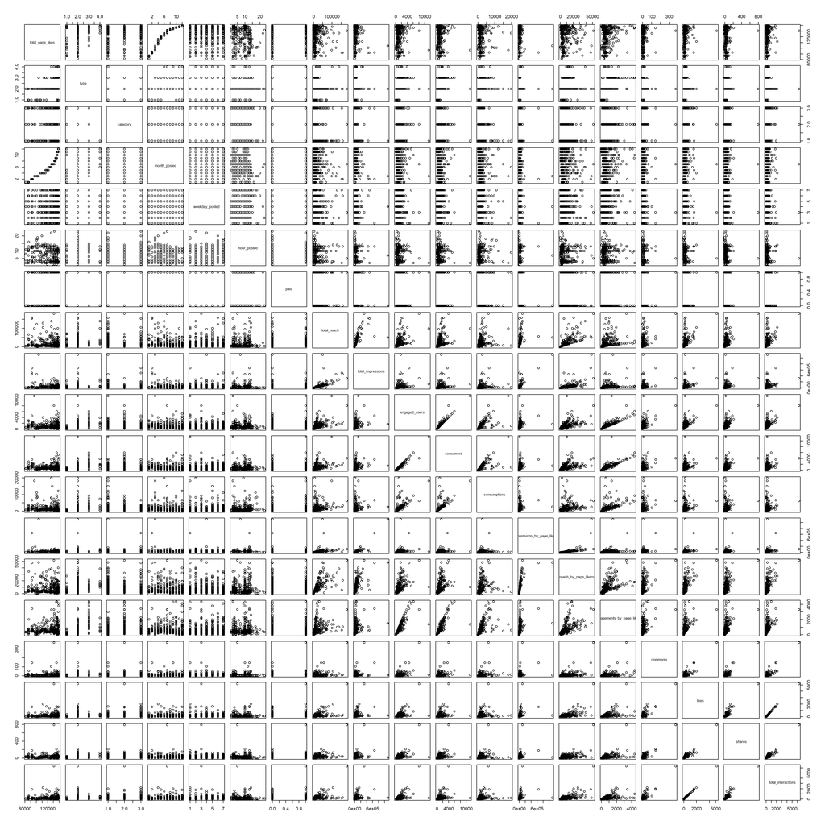

```r
plot(facebook)
```

## Data Distributions

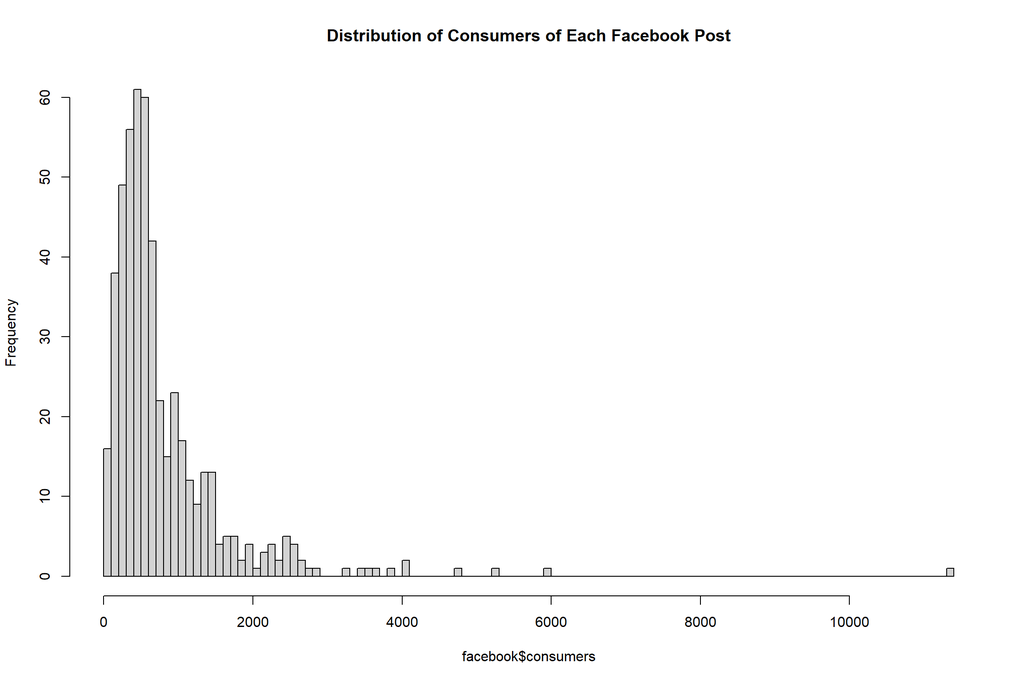

```r
hist(x = facebook$consumers,
     breaks = 100,
     main = "Distribution of Consumers of Each Facebook Post")
```

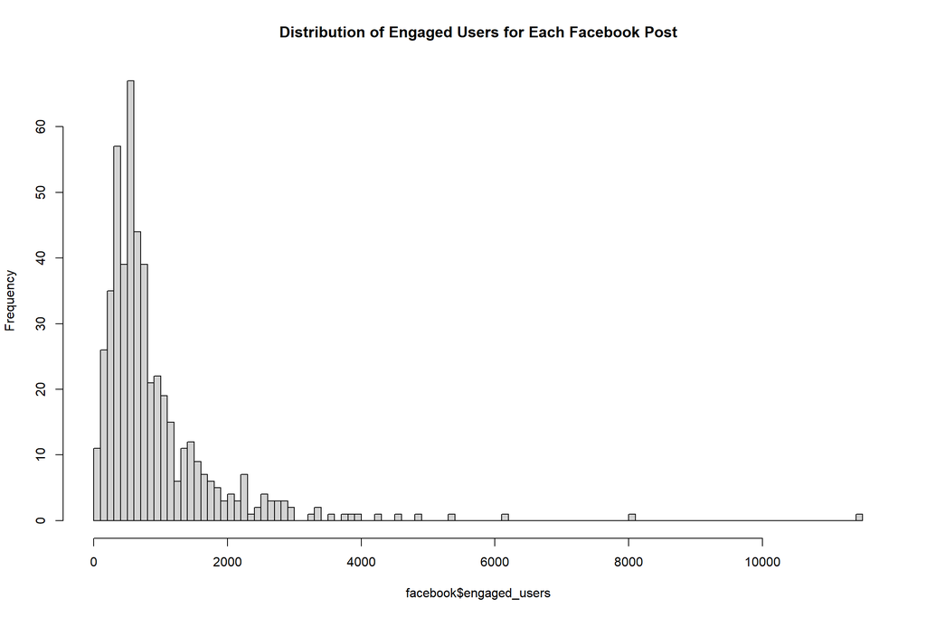

```r
hist(x = facebook$engaged_users,
     breaks = 100,
     main = "Distribution of Engaged Users for Each Facebook Post")
```

## Data Transformations

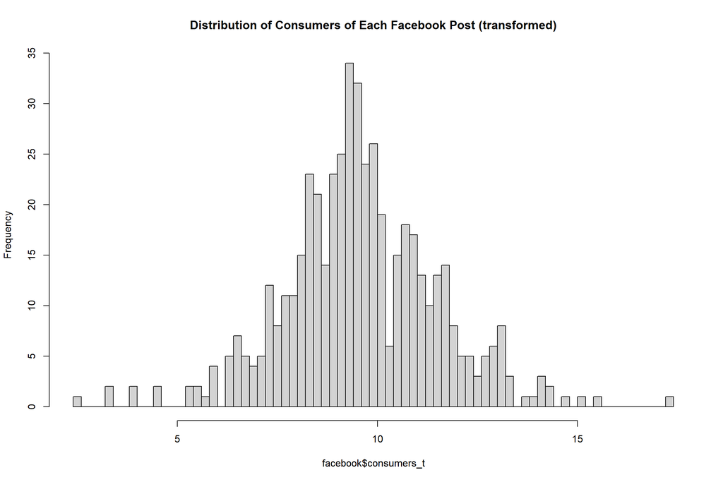

```r
bcPower(U = facebook$consumers,
        lambda = powerTransform(facebook$consumers)$lambda) -> facebook$consumers_t

hist(facebook$consumers_t, breaks = 60,
     main = "Distribution of Consumers of Each Facebook Post (transformed)")
```

```r
shapiro.test(bcPower(U = facebook$consumers,
                     lambda = powerTransform(facebook$consumers)$lambda))
```

```
##
##  Shapiro-Wilk normality test
##
## data:  bcPower(U = facebook$consumers, lambda = powerTransform(facebook$consumers)$lambda)
## W = 0.98669, p-value = 0.0001567
```

The Shapiro-Wilk test of normality results in a p-value of 0.0001567 which means we reject the null hypothesis and there is evidence that the distribution of consumers of each Facebook post after the power transformation is not normal.

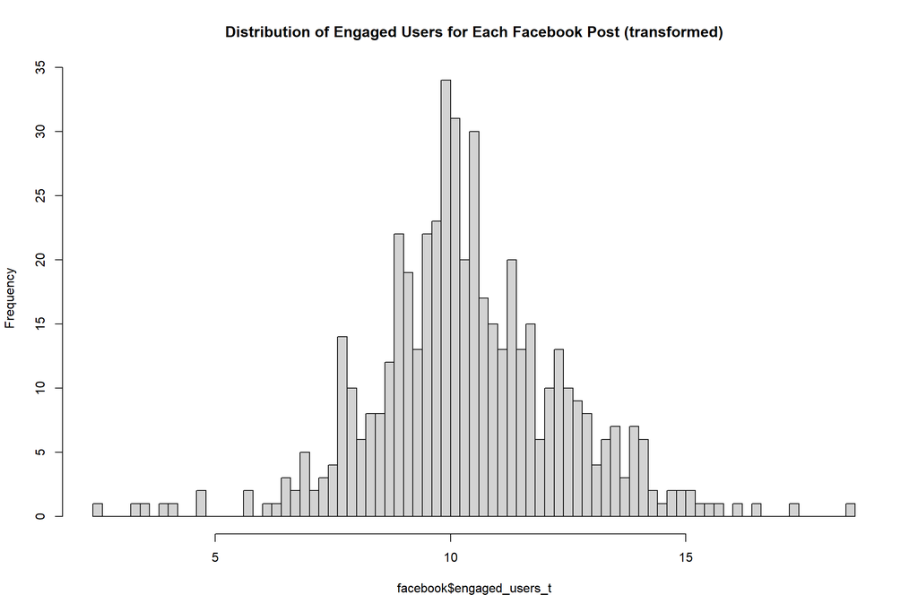

```r
bcPower(U = facebook$engaged_users,
        lambda = powerTransform(facebook$engaged_users)$lambda) -> facebook$engaged_users_t

hist(facebook$engaged_users_t, breaks = 60,
     main = "Distribution of Engaged Users for Each Facebook Post (transformed)")
```

```r
shapiro.test(bcPower(U = facebook$engaged_users,
                     lambda = powerTransform(facebook$engaged_users)$lambda))
```

```
##
##  Shapiro-Wilk normality test
##
## data:  bcPower(U = facebook$engaged_users, lambda = powerTransform(facebook$engaged_users)$lambda)
## W = 0.98103, p-value = 4.192e-06
```

The Shapiro-Wilk test of normality results in a p-value of 4.192e-06 which means we reject the null hypothesis and there is evidence that the distribution of engaged users for each Facebook post after the power transformation is not normal.

## Linear Regression

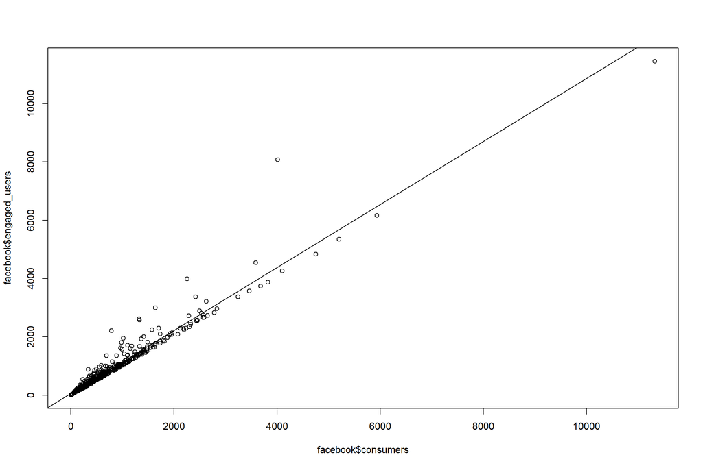

```r
plot(facebook$consumers, facebook$engaged_users)
abline(lsfit(facebook$consumers, facebook$engaged_users))
```

```r
summary(lm(engaged_users ~ consumers, data = facebook))
```

```
##
## Call:
## lm(formula = engaged_users ~ consumers, data = facebook)
##
## Residuals:
##    Min     1Q Median     3Q    Max
## -847.1  -72.7  -45.4    1.3 3681.3
##
## Coefficients:
##             Estimate Std. Error t value Pr(>|t|)
## (Intercept) 57.12660   14.88315   3.838  0.00014 ***
## consumers    1.08068    0.01251  86.382  < 2e-16 ***
## ---
## Signif. codes:  0 '***' 0.001 '**' 0.01 '*' 0.05 '.' 0.1 ' ' 1
##
## Residual standard error: 246.6 on 498 degrees of freedom
## Multiple R-squared:  0.9374, Adjusted R-squared:  0.9373
## F-statistic:  7462 on 1 and 498 DF,  p-value: < 2.2e-16
```

The summary shows that the independent variable is statistically significant with a p-value < 2e-16. For every unit change in consumers, we expect a 1.08 increase in engaged users. The model has an adjusted R-squared of 0.9373 with a p-value < 2.2e-16.

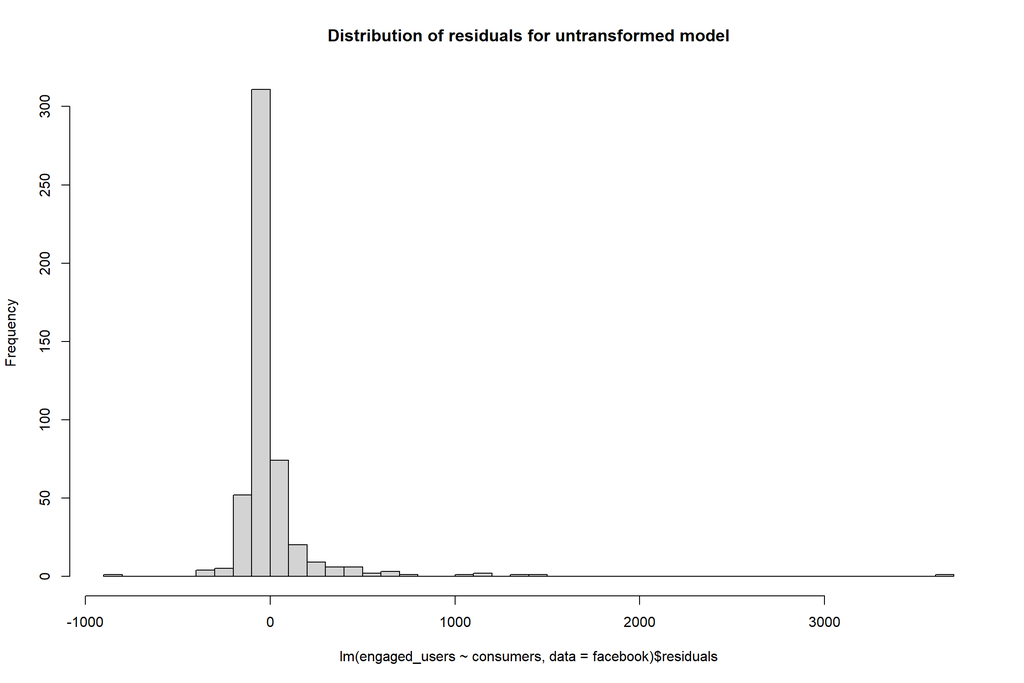

```r
hist(lm(engaged_users ~ consumers, data = facebook)$residuals, breaks = 60,
     main = "Distribution of residuals for untransformed model")
```

The distribution of residuals is not normal.

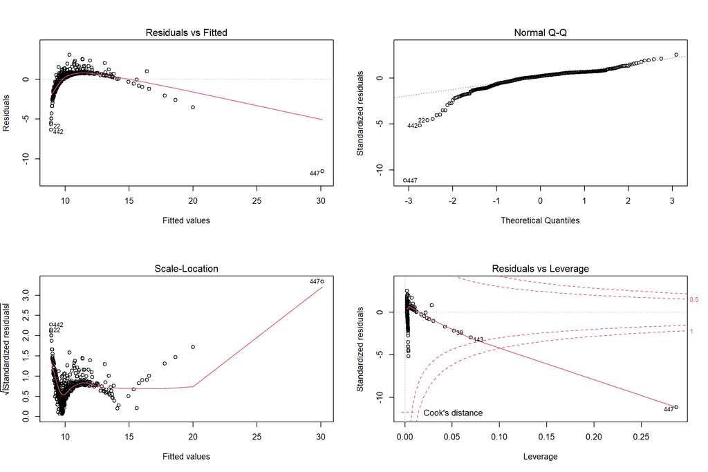

```r
par(mfrow = c(2,2))
plot(lm(engaged_users_t ~ consumers, data = facebook))
```

The plot of residuals against the fitted values shows a distinct pattern and a curved line which indicates that this isn’t a linear relationship. The standardized residuals in the normal QQ plot do not follow the dashed line which indicates they are likely not normally distributed. The scale-location plot does not show a constant variance of the residuals which indicates the data is not homoscedastic. The residuals vs leverage plot shows that some points exceed a standardized residual of greater than 3 which may indicate the presence of outliers, as well as some extreme points such as 39, 143, 447.

## Linear Regression (transformed)

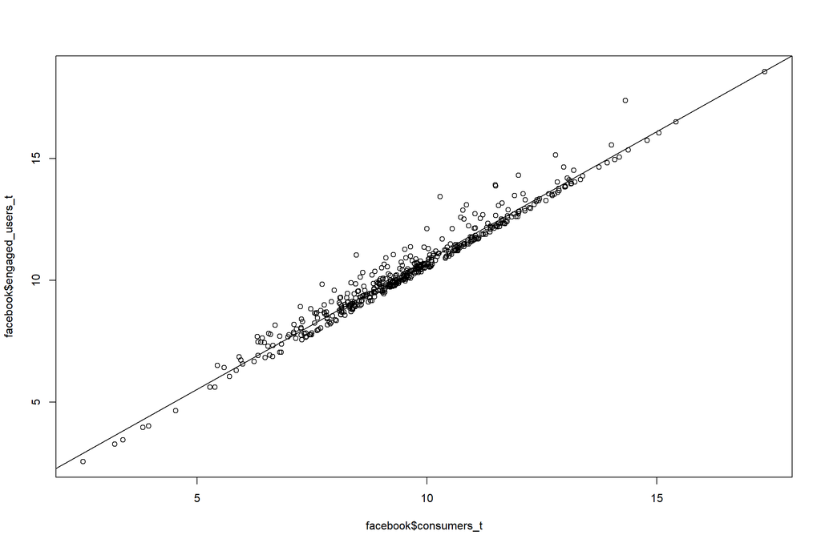

```r
plot(facebook$consumers_t, facebook$engaged_users_t)
abline(lsfit(facebook$consumers_t, facebook$engaged_users_t))
```

```r
summary(lm(engaged_users_t ~ consumers_t, data = facebook))
```

```
##
## Call:
## lm(formula = engaged_users_t ~ consumers_t, data = facebook)
##
## Residuals:
##      Min       1Q   Median       3Q      Max
## -0.40804 -0.23079 -0.12633  0.08964  2.32249
##
## Coefficients:
##             Estimate Std. Error t value Pr(>|t|)
## (Intercept) 0.237026   0.087064   2.722  0.00671 **
## consumers_t 1.057941   0.008917 118.637  < 2e-16 ***
## ---
## Signif. codes:  0 '***' 0.001 '**' 0.01 '*' 0.05 '.' 0.1 ' ' 1
##
## Residual standard error: 0.3815 on 498 degrees of freedom
## Multiple R-squared:  0.9658, Adjusted R-squared:  0.9658
## F-statistic: 1.407e+04 on 1 and 498 DF,  p-value: < 2.2e-16
```

The summary shows that the independent variable is statistically significant with a p-value < 2e-16. For every unit change in consumers, we expect a 1.05 increase in engaged users. The model has an adjusted R-squared of 0.9658 with a p-value < 2.2e-16.

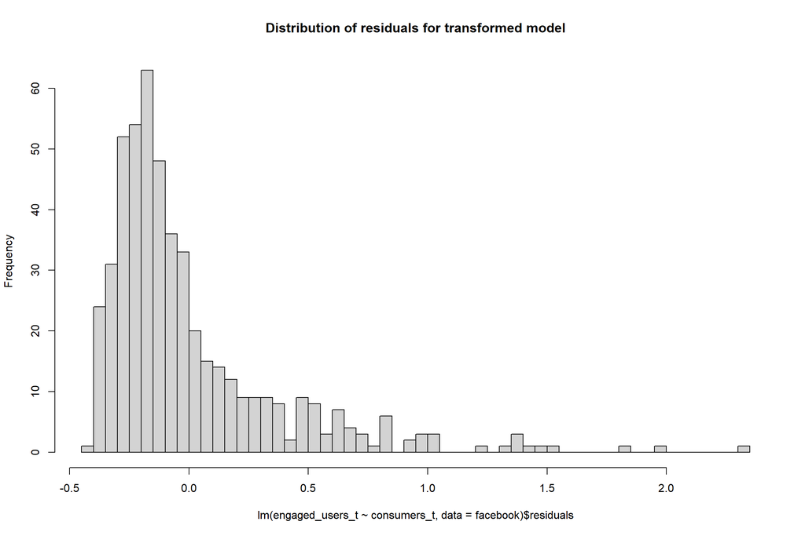

```r
hist(lm(engaged_users_t ~ consumers_t, data = facebook)$residuals, breaks = 60,
     main = "Distribution of residuals for transformed model")
```

The distribution of residuals is not normal.

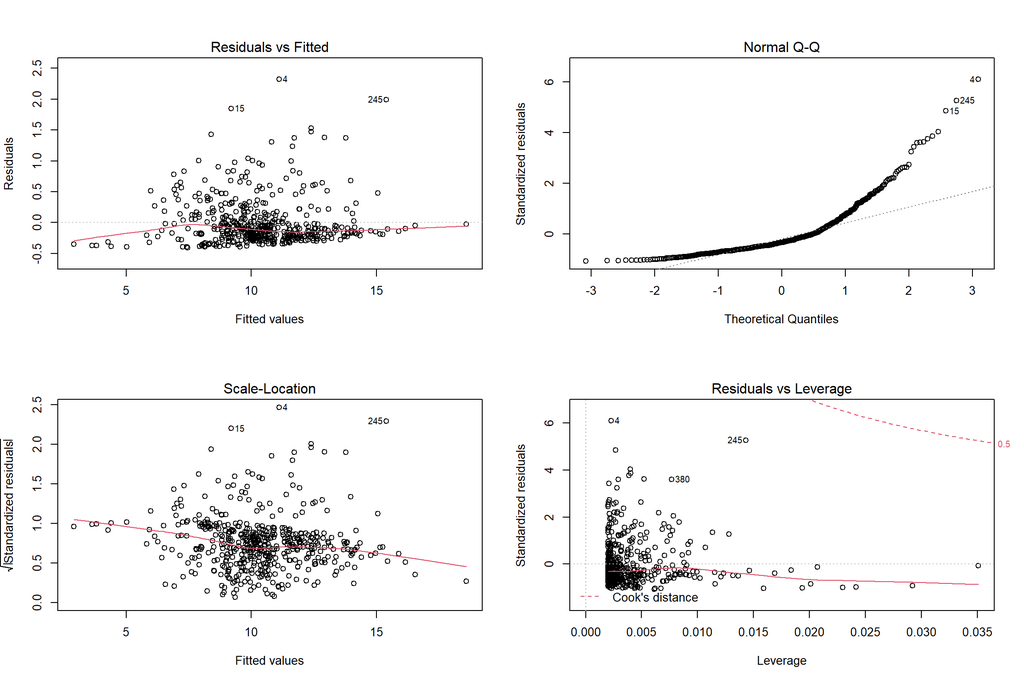

```r
par(mfrow = c(2,2))
plot(lm(engaged_users_t ~ consumers_t, data = facebook))
```

The plot of residuals against the fitted values shows less of a distinct pattern after the transformation and the line is more straight and horizontal. The standardized residuals in the normal QQ plot still do not follow the dashed line which indicates they are likely still not normally distributed. The scale-location plot shows a more constant variance of the residuals but there seems to be a cluster of residuals for fitted values near 10. The residuals vs leverage shows that some points exceed a standardized residual of greater than 3 which may indicate the presence of outliers, as well as some extreme points such as 380, 4, and 245.